# Stat418 HW3

Ruifu Jiang

# 1 Input data

The first step is downloading and inputing the dataset to R. The purpose is to find what predictors influence the income over 50k. Then transfered the response variable to “0” if income is less or equal to 50k and “1” if income is greater than 50k. And split data into train, validation and test set with ratio 6:2:2.

```r
col_names <- c("age", "workclass", "fnlwgt", "education", "education-num", "marital-status", "occupation", "relationship", "race", "sex", "capital-gain", "capital-loss", "hours-per-week", "native-country","Y")
adult.data<- read.csv("/Users/Ruifu/Downloads/adult.data.csv", header = FALSE, col.names = col_names)

adult.data$Y<- as.character(adult.data$Y)
adult.data$Y<- ifelse(adult.data$Y ==" >50K",1,0)

set.seed(123)
N <- nrow(adult.data)
idx <- sample(seq(1, 3), size = N, replace = TRUE, prob = c(.6, .2, .2))
adult_train <- adult.data[idx == 1,]
adult_vali<- adult.data[idx == 2,]
adult_test <- adult.data[idx == 3,]
```

# ML analysis with R package

## 1 LR

First is to try the logestic regression with the best lambda 0.000498676.

```r
library(glmnet)
```

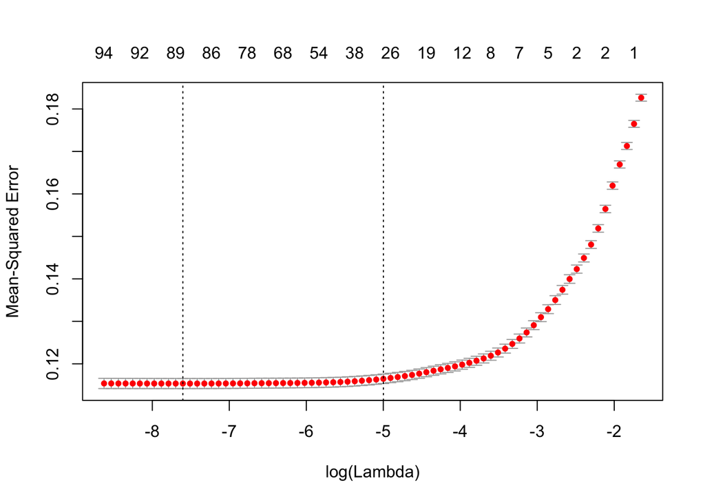

```r
X <- Matrix::sparse.model.matrix(Y ~ . - 1, data = adult.data)
X_train <- X[idx == 1,]
X_vali<- X[idx == 2,]
X_test <- X[idx == 3,]

md <- cv.glmnet(X_train, adult_train$Y)
plot(md)
```

```r
md <- glmnet( X_train, adult_train$Y, family = "binomial", lambda = 0.000498676)
```

```r
library(ROCR)
phat <- predict(md, newx = X_test, type = "response")

rocr_pred <- prediction(phat, adult_test$Y)
performance(rocr_pred, "auc")@y.values[[1]]
```

```
## [1] 0.9039013
```

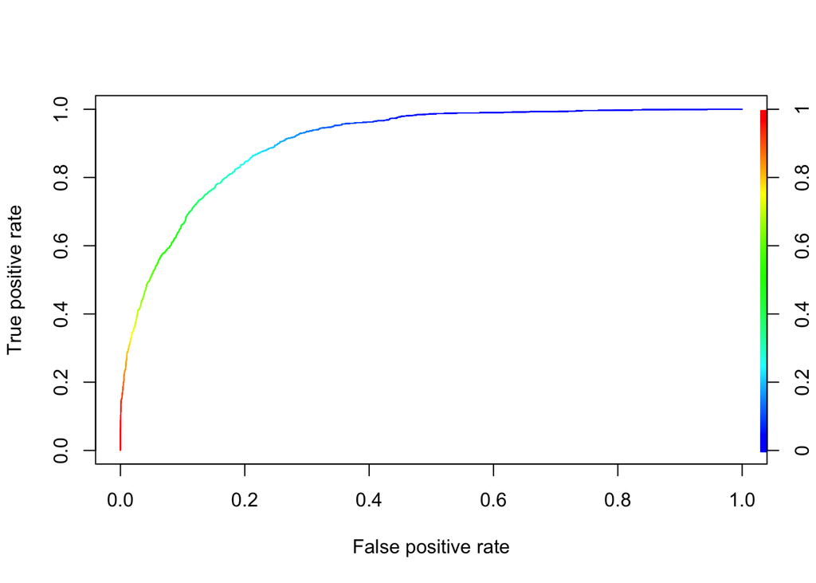

```r
plot(performance(rocr_pred, "tpr", "fpr"), colorize = T)
```

The AUC is close to 1 which means this model is a good fit.  
As we can see from the plot, when the true positive rate increases, the false positive rate increases as well. The AUC is the area under the curve. As long as the area close to 1, it becomes easier to find a point where the true positive rate is high and the false positive rate is low.

## 2 RF

Then try to build model with Random Forest method. First is to set different number of trees and depth of trees to get different models with train set. And use validation set to choose the best model with the biggest AUC. finally use the test set to test the best model.

```r
library(randomForest)
set.seed(123)
RF1<- randomForest(as.factor(Y) ~ ., data = adult_train, ntree = 100, depth = 5)
RF2<- randomForest(as.factor(Y) ~ ., data = adult_train, ntree = 10, depth = 5)
RF3<- randomForest(as.factor(Y) ~ ., data = adult_train, ntree = 100, depth = 10)

RF1phat<- predict(RF1, adult_vali, type = "prob")[,"1"]
RF1rocr_pred <- prediction(RF1phat, adult_vali$Y)
performance(RF1rocr_pred, "auc")@y.values[[1]]
```

```
## [1] 0.8878004
```

```r
RF2phat<- predict(RF2, adult_vali, type = "prob")[,"1"]
RF2rocr_pred <- prediction(RF2phat, adult_vali$Y)
performance(RF2rocr_pred, "auc")@y.values[[1]]
```

```
## [1] 0.8237337
```

```r
RF3phat<- predict(RF3, adult_vali, type = "prob")[,"1"]
RF3rocr_pred <- prediction(RF3phat, adult_vali$Y)
performance(RF3rocr_pred, "auc")@y.values[[1]]
```

```
## [1] 0.8856741
```

```r
RF1
```

```
##
## Call:
##  randomForest(formula = as.factor(Y) ~ ., data = adult_train,      ntree = 100, depth = 5)
##                Type of random forest: classification
##                      Number of trees: 100
## No. of variables tried at each split: 3
##
##         OOB estimate of  error rate: 17.44%
## Confusion matrix:
##       0    1 class.error
## 0 14822   89 0.005968748
## 1  3335 1391 0.705670758
```

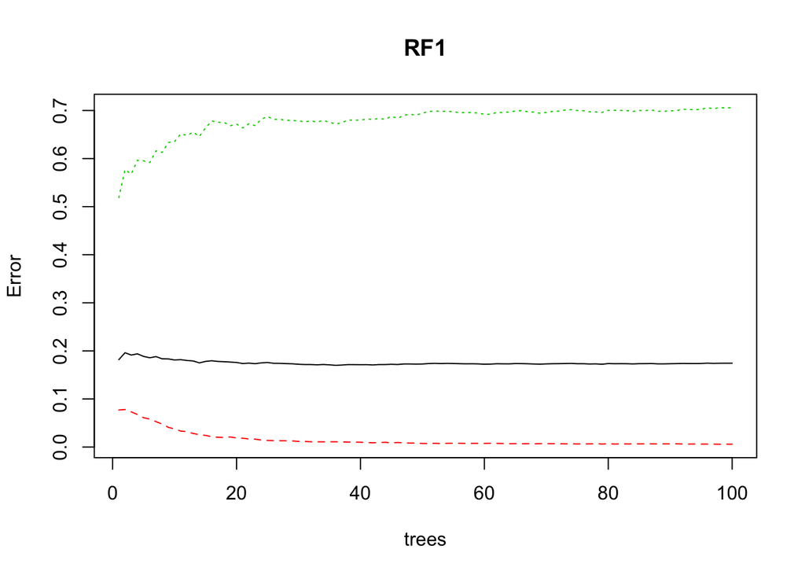

```r
plot(RF1)
```

Actually, we can write a loop for each parameter to try different number and compare each AUC to get the best number. As this cost too much time in my laptop, I choose several numbers instead.

Then use random forest cross validation to find the best number of columns used in each split which is 7.

```r
rfcv(adult_train[ ,-15],as.factor(adult_train$Y))
```

[output not shown]

[output cut: 2316 more lines]

Finally test this model with test set. The AUC of this model is 0.863745

```r
RF<- randomForest(as.factor(Y) ~ ., data = adult_train, ntree = 100, depth = 5, mtry = 7)
RFphat <- predict(RF, adult_test, type = "prob")[,"1"]
RFrocr_pred <- prediction(RFphat, adult_test$Y)
performance(RFrocr_pred, "auc")@y.values[[1]]
```

```
## [1] 0.863745
```

## 3 GBM

```r
library(gbm)
set.seed(123)

md <- gbm(Y ~ ., data = adult_train, distribution = "bernoulli",
          n.trees = 100, interaction.depth = 10, shrinkage = 0.01)

yhat <- predict(md, adult_test, n.trees = 100)
table(ifelse(yhat>0,1,0), adult_test$Y)
```

```
##
##        0    1
##   0 4725  807
##   1  158  772
```

```
## Using cv method...
```

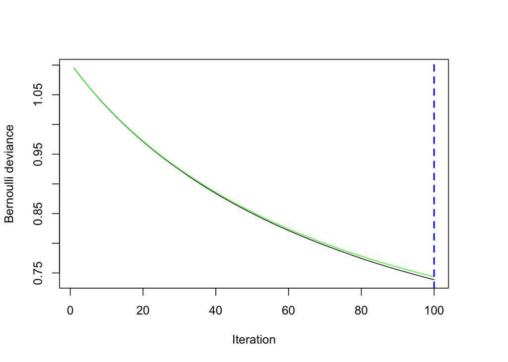

```
## [1] 100
```

```r
md <- gbm(Y ~ ., data = adult_train, distribution = "bernoulli",
          n.trees = 100, interaction.depth = 10, shrinkage = 0.01, cv.folds = 5)
gbm.perf(md, plot.it = TRUE)
```

```
## Using cv method...
```

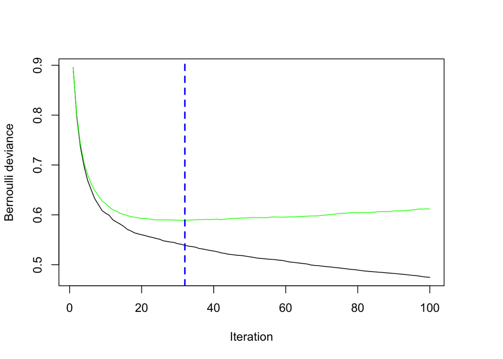

```
## [1] 32
```

```r
md <- gbm(Y ~ ., data = adult_train, distribution = "bernoulli",
          n.trees = 100, interaction.depth = 10, shrinkage = 0.3, cv.folds = 5)
gbm.perf(md, plot.it = TRUE)
```

```r
yhat <- predict(md, adult_test, n.trees = gbm.perf(md, plot.it = FALSE))
```

```
## Using cv method...
```

```r
GBM_pred <- prediction(yhat, adult_test$Y)
performance(GBM_pred, "auc")@y.values[[1]]
```

```
## [1] 0.9186513
```

# ML analysis with h2o

The porcedure of analyzing with h2o is pretty similar to the one with R package. Key code is show below.

## 1 LR

```r
library(h2o)
h2o.init(nthreads=-1)
```

[output not shown]

```r
dx <- h2o.importFile("/Users/Ruifu/Downloads/adult.data.csv")
dx_split <- h2o.splitFrame(dx, ratios = 0.6, seed = 123)
dx_train <- dx_split[[1]]
dx_test <- dx_split[[2]]
Xnames <- names(dx_train)[which(names(dx_train)!="C15")]

md <- h2o.glm(x = Xnames, y = "C15", training_frame = dx_train,
              family = "binomial", alpha = 1, lambda = 0)
h2o.auc(h2o.performance(md, dx_test))
```

```
## [1] 0.9048536
```

```r
md
```

```
## Model Details:
## ==============
##
## H2OBinomialModel: glm
## Model ID:  GLM_model_R_1495602994117_771
## GLM Model: summary
##     family  link regularization number_of_predictors_total
## 1 binomial logit           None                        100
##   number_of_active_predictors number_of_iterations  training_frame
## 1                         100                    5 RTMP_sid_a986_2
##
## Coefficients: glm coefficients
##          names coefficients standardized_coefficients
## 1    Intercept   -43.561857                 16.592593
## 2 C14.Cambodia     1.865485                  1.865485
## 3   C14.Canada     0.646464                  0.646464
## 4    C14.China     0.024900                  0.024900
## 5 C14.Columbia    -3.320870                 -3.320870
##
## ---
##     names coefficients standardized_coefficients
## 96     C1     0.026987                  0.366536
## 97     C3     0.000001                  0.063817
## 98     C5     5.695195                 14.640440
## 99    C11     0.000334                  2.455995
## 100   C12     0.000649                  0.262282
## 101   C13     0.027344                  0.336918
##
## H2OBinomialMetrics: glm
## ** Reported on training data. **
##
## MSE:  0.1004941
## RMSE:  0.3170081
## LogLoss:  0.3138516
## Mean Per-Class Error:  0.1880976
## AUC:  0.9102855
## Gini:  0.8205709
## R^2:  0.4508428
## Null Deviance:  21660.81
## Residual Deviance:  12306.75
## AIC:  12508.75
##
## Confusion Matrix (vertical: actual; across: predicted) for F1-optimal threshold:
##        <=50K >50K    Error         Rate
## <=50K  12969 1909 0.128310  =1909/14878
## >50K    1172 3556 0.247885   =1172/4728
## Totals 14141 5465 0.157146  =3081/19606
##
## Maximum Metrics: Maximum metrics at their respective thresholds
##                         metric threshold    value idx
## 1                       max f1  0.348754 0.697734 212
## 2                       max f2  0.137910 0.794981 303
## 3                 max f0point5  0.554577 0.716365 138
## 4                 max accuracy  0.547836 0.854126 140
## 5                max precision  0.995154 0.993548   3
## 6                   max recall  0.001305 1.000000 397
## 7              max specificity  0.999849 0.999866   0
## 8             max absolute_mcc  0.386154 0.596409 198
## 9   max min_per_class_accuracy  0.273154 0.822288 243
## 10 max mean_per_class_accuracy  0.203205 0.827969 273
##
## Gains/Lift Table: Extract with `h2o.gainsLift(<model>, <data>)` or `h2o.gainsLift(<model>, valid=<T/F>, xval=<T/F>)`
```

## 2 RF

```r
md <- h2o.randomForest(x = Xnames, y = "C15", training_frame = dx_train, ntrees = 500)
h2o.auc(h2o.performance(md, dx_test))
```

```
## [1] 0.9122087
```

```r
md
```

```
## Model Details:
## ==============
##
## H2OBinomialModel: drf
## Model ID:  DRF_model_R_1495602994117_774
## Model Summary:
##   number_of_trees number_of_internal_trees model_size_in_bytes min_depth
## 1             500                      500            10210472        20
##   max_depth mean_depth min_leaves max_leaves mean_leaves
## 1        20   20.00000       1193       1782  1481.57000
##
##
## H2OBinomialMetrics: drf
## ** Reported on training data. **
## ** Metrics reported on Out-Of-Bag training samples **
##
## MSE:  0.09413384
## RMSE:  0.3068124
## LogLoss:  0.2999583
## Mean Per-Class Error:  0.1811059
## AUC:  0.9177553
## Gini:  0.8355107
##
## Confusion Matrix (vertical: actual; across: predicted) for F1-optimal threshold:
##        <=50K >50K    Error         Rate
## <=50K  13369 1509 0.101425  =1509/14878
## >50K    1233 3495 0.260787   =1233/4728
## Totals 14602 5004 0.139855  =2742/19606
##
## Maximum Metrics: Maximum metrics at their respective thresholds
##                         metric threshold    value idx
## 1                       max f1  0.394561 0.718249 200
## 2                       max f2  0.182600 0.793128 290
## 3                 max f0point5  0.600028 0.749013 128
## 4                 max accuracy  0.496839 0.866010 162
## 5                max precision  0.999438 1.000000   0
## 6                   max recall  0.000020 1.000000 399
## 7              max specificity  0.999438 1.000000   0
## 8             max absolute_mcc  0.407588 0.626509 195
## 9   max min_per_class_accuracy  0.289918 0.831160 245
## 10 max mean_per_class_accuracy  0.283553 0.832471 247
##
## Gains/Lift Table: Extract with `h2o.gainsLift(<model>, <data>)` or `h2o.gainsLift(<model>, valid=<T/F>, xval=<T/F>)`
```

## 3 GBM

```r
md <- h2o.gbm(x = Xnames, y = "C15", training_frame = dx_train, distribution = "bernoulli",
                ntrees = 100, max_depth = 10, learn_rate = 0.01,
                nbins = 100, seed = 123)
md
```

```
## Model Details:
## ==============
##
## H2OBinomialModel: gbm
## Model ID:  GBM_model_R_1495602994117_839
## Model Summary:
##   number_of_trees number_of_internal_trees model_size_in_bytes min_depth
## 1             100                      100              392860        10
##   max_depth mean_depth min_leaves max_leaves mean_leaves
## 1        10   10.00000        188        255   211.55000
##
##
## H2OBinomialMetrics: gbm
## ** Reported on training data. **
##
## MSE:  0.09534359
## RMSE:  0.3087776
## LogLoss:  0.3256388
## Mean Per-Class Error:  0.1405877
## AUC:  0.9468874
## Gini:  0.8937747
##
## Confusion Matrix (vertical: actual; across: predicted) for F1-optimal threshold:
##        <=50K >50K    Error         Rate
## <=50K  13360 1518 0.102030  =1518/14878
## >50K     847 3881 0.179146    =847/4728
## Totals 14207 5399 0.120626  =2365/19606
##
## Maximum Metrics: Maximum metrics at their respective thresholds
##                         metric threshold    value idx
## 1                       max f1  0.310022 0.766466 209
## 2                       max f2  0.209603 0.837948 276
## 3                 max f0point5  0.463138 0.800506 122
## 4                 max accuracy  0.380573 0.888657 167
## 5                max precision  0.761798 1.000000   0
## 6                   max recall  0.093036 1.000000 391
## 7              max specificity  0.761798 1.000000   0
## 8             max absolute_mcc  0.362987 0.689863 177
## 9   max min_per_class_accuracy  0.282060 0.863759 227
## 10 max mean_per_class_accuracy  0.261465 0.868683 240
##
## Gains/Lift Table: Extract with `h2o.gainsLift(<model>, <data>)` or `h2o.gainsLift(<model>, valid=<T/F>, xval=<T/F>)`
```

```r
md <- h2o.gbm(x = Xnames, y = "C15", training_frame = dx_train, distribution = "bernoulli",
                ntrees = 10, max_depth = 10, learn_rate = 0.01,
                nbins = 100, seed = 123)
md
```

```
## Model Details:
## ==============
##
## H2OBinomialModel: gbm
## Model ID:  GBM_model_R_1495602994117_910
## Model Summary:
##   number_of_trees number_of_internal_trees model_size_in_bytes min_depth
## 1              10                       10               39384        10
##   max_depth mean_depth min_leaves max_leaves mean_leaves
## 1        10   10.00000        197        232   213.80000
##
##
## H2OBinomialMetrics: gbm
## ** Reported on training data. **
##
## MSE:  0.16544
## RMSE:  0.4067432
## LogLoss:  0.5063238
## Mean Per-Class Error:  0.148172
## AUC:  0.9361351
## Gini:  0.8722701
##
## Confusion Matrix (vertical: actual; across: predicted) for F1-optimal threshold:
##        <=50K >50K    Error         Rate
## <=50K  12763 2115 0.142156  =2115/14878
## >50K     729 3999 0.154188    =729/4728
## Totals 13492 6114 0.145058  =2844/19606
##
## Maximum Metrics: Maximum metrics at their respective thresholds
##                         metric threshold    value idx
## 1                       max f1  0.249170 0.737687 182
## 2                       max f2  0.233677 0.823763 270
## 3                 max f0point5  0.271437 0.773573 108
## 4                 max accuracy  0.265998 0.877384 124
## 5                max precision  0.314963 1.000000   0
## 6                   max recall  0.218460 1.000000 394
## 7              max specificity  0.314963 1.000000   0
## 8             max absolute_mcc  0.262058 0.653968 137
## 9   max min_per_class_accuracy  0.248616 0.852937 185
## 10 max mean_per_class_accuracy  0.246092 0.855806 198
##
## Gains/Lift Table: Extract with `h2o.gainsLift(<model>, <data>)` or `h2o.gainsLift(<model>, valid=<T/F>, xval=<T/F>)`
```

```r
md <- h2o.gbm(x = Xnames, y = "C15", training_frame = dx_train, distribution = "bernoulli",
                ntrees = 100, max_depth = 20, learn_rate = 0.3,
                nbins = 100, seed = 123)
md
```

```
## Model Details:
## ==============
##
## H2OBinomialModel: gbm
## Model ID:  GBM_model_R_1495602994117_933
## Model Summary:
##   number_of_trees number_of_internal_trees model_size_in_bytes min_depth
## 1             100                      100             1021340         0
##   max_depth mean_depth min_leaves max_leaves mean_leaves
## 1        20   16.31000          1       1213   711.88000
##
##
## H2OBinomialMetrics: gbm
## ** Reported on training data. **
##
## MSE:  3.515915e-05
## RMSE:  0.005929515
## LogLoss:  0.001053977
## Mean Per-Class Error:  3.360667e-05
## AUC:  1
## Gini:  1
##
## Confusion Matrix (vertical: actual; across: predicted) for F1-optimal threshold:
##        <=50K >50K    Error      Rate
## <=50K  14877    1 0.000067  =1/14878
## >50K       0 4728 0.000000   =0/4728
## Totals 14877 4729 0.000051  =1/19606
##
## Maximum Metrics: Maximum metrics at their respective thresholds
##                         metric threshold    value idx
## 1                       max f1  0.498356 0.999894 203
## 2                       max f2  0.498356 0.999958 203
## 3                 max f0point5  0.895988 0.999958 202
## 4                 max accuracy  0.895988 0.999949 202
## 5                max precision  0.999995 1.000000   0
## 6                   max recall  0.498356 1.000000 203
## 7              max specificity  0.999995 1.000000   0
## 8             max absolute_mcc  0.498356 0.999861 203
## 9   max min_per_class_accuracy  0.498356 0.999933 203
## 10 max mean_per_class_accuracy  0.498356 0.999966 203
##
## Gains/Lift Table: Extract with `h2o.gainsLift(<model>, <data>)` or `h2o.gainsLift(<model>, valid=<T/F>, xval=<T/F>)`
```

```r
h2o.auc(h2o.performance(md, dx_test))
```

```
## [1] 0.8990991
```

In h2o, we have several way for early stopping.  
First, stop model building if misclassification improves (goes down) by less than one percent between individual scoring events. (stopping_rounds=1, stopping_tolerance=0.01, stopping_metric=“misclassification”)  
second, stop model building if the logloss on the validation set does not improve at all for 3 consecutive scoring events. (validation_frame, stopping_rounds=3, stopping_tolerance=0, stopping metric=“logloss”)  
Third, stop model building if the simple moving average (window length 5) of the AUC improves (goes up) by less than 0.1 percent for 5 consecutive scoring events. (stopping_rounds=5, stopping_tolerance=0.001, stopping_metric=“AUC”)  
Fourth, stop model training after a given amount of seconds. (max runtime secs > 0)